```python
import numpy as np
import pandas as pd
import seaborn as sns
import statistics
import matplotlib.cm as cm
import matplotlib.colors as colors
import matplotlib.gridspec as gridspec
import matplotlib.pyplot as plt
import folium
from folium import plugins
from sklearn import preprocessing
from sklearn.neighbors import NearestNeighbors
from sklearn.preprocessing import StandardScaler
from sklearn.cluster import DBSCAN
from sklearn.cluster import OPTICS, cluster_optics_dbscan
from sklearn import metrics
from sklearn.datasets import make_blobs
from scipy.spatial.distance import pdist, squareform
from sklearn import datasets
from datetime import datetime
from pandas import Timestamp
import networkx as nx

%load_ext autoreload
%autoreload 2

from odmatrix import ODMatrix
from bisecting_kmeans import BisectingKMeans
from prefspan import PSpan
```

# CLUSTERING ALGORITHMS TABLE

```python
table = pd.read_excel('../csv/table_clustering.xlsx')
table.drop(['Unnamed: 0'], axis='columns', inplace=True)
highlight = lambda x: ['background: #f2dbaa' if x.name in [5,6] else '' for i in x]
table = table.style
table = table.hide_index()
table = table.apply(highlight, axis=1)
table
```

| Algorithm | Parameters | N. Clusters | Perc. Outliers | Mean (cluster dimension) | Median (cluster dimension) | Biggest cluster dimension | Silhouette |
| --- | --- | --- | --- | --- | --- | --- | --- |
| Optics1 | min_samples=10, default metric=minkowski | 17 | 19.152276 | 39 | 16.000000 | 161 | 0.629730 |
| Optics2 | min_samples=50, xi=0.05, min_cluuster_size=0.05 | 8 | 26.216641 | 91 | 64.000000 | 167 | 0.528897 |
| Optics3 | min_samples=10, metric=cityblock | 17 | 19.152276 | 39 | 16.000000 | 161 | 0.625365 |
| Dbscan1 | eps=0.2, min_samples=5 | 15 | 9.733124 | 45 | 12.500000 | 306 | 0.701445 |
| Dbscan2 | eps=0.3, min_samples=5 | 10 | 7.064364 | 70 | 16.000000 | 310 | 0.734527 |
| Dbscan3 | eps=0.2, min_samples=3 | 25 | 3.767661 | 26 | 6.000000 | 306 | 0.755483 |
| Biisecting-Kmeans | min_cluster_size=1, max_distance_thr=100/1000 (km), metric=haversine, random_state=0 | 52 | 2.511774 | 12 | 4.000000 | 163 | 0.817751 |

Noto che Bisecting Kmeans e Dbscan3 hanno risultati migliori, perciò scelgo questi due.

# Data preparation

```python
df = pd.read_csv('../csv/df_uidFiles_2016.csv')
df.drop(['Unnamed: 0'], axis='columns', inplace=True)
```

Creo un dataframe contenente soltanto le coordinate (lat e long unite):

```python
df_coords = df['Coords']
df_coords
```

```
0      [43.72666207, 10.41268069]
1      [43.72666207, 10.41268069]
2      [43.72666207, 10.41268069]
3              [43.7167, 10.3833]
4            [43.70561, 10.42059]
                  ...
632            [43.7167, 10.3833]
633            [43.7167, 10.3833]
634            [43.7167, 10.3833]
635    [43.71544235, 10.40051616]
636           [43.72263, 10.3948]
Name: Coords, Length: 637, dtype: object
```

### Definisco latitudine e longitudine per le mappe

```python
lat = [43.7359, 43.6955]
lon = [10.4269, 10.3686]

lat_mean = np.mean(lat)
lon_mean = np.mean(lon)

lat, lng = (lat_mean, lon_mean)

loc=[lat, lng]
```

## Normalzzo i dati

Creo il dataframe X che contiene soltanto la colonna della lat e della lon e poi normalizzo i dati per il clustering.

```python
X = df[['Lat', 'Lon']]
X_norm = StandardScaler().fit_transform(X)

X_norm
```

```
array([[ 1.21862633,  2.50548165],
       [ 1.21862633,  2.50548165],
       [ 1.21862633,  2.50548165],
       ...,
       [-0.46658272, -1.48740575],
       [-0.67932998,  0.85230065],
       [ 0.53655113,  0.07546446]])
```

# DBSCAN3

## Knee method with Nearest Neighbors

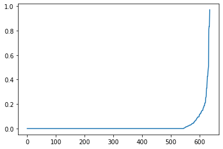

```python
neigh = NearestNeighbors(n_neighbors=2)
nbrs = neigh.fit(X_norm)
# .kneighbors finds the K-neighbors of a point and returns indices of and distances to the neighbors of each point.
distances, indices = nbrs.kneighbors(X_norm)
distances = np.sort(distances, axis=0)
distances = distances[:,1]
plt.plot(distances)
```

Sembrerebbe essere intorno a eps=0.2

## Knee method with pair wise distances between observations in n-dimensional space

Utilizzo il knee method per trovare i parametri più adatti.

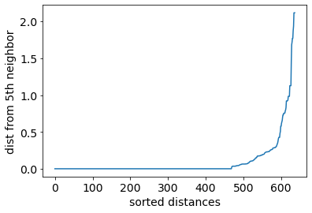

```python
distance = pdist(X_norm, 'euclidean') #pair wise distances between observations in n-dimensional space
#squareform converts between condensed distance matrices and square distance matrices
distance = squareform(distance) #distance matrix given the vector distance
k = 5
kth_distances = list()
for d in distance:
    index_kth_distance = np.argsort(d)[k]
    kth_distances.append(d[index_kth_distance])

plt.plot(range(0, len(kth_distances)), sorted(kth_distances))
plt.ylabel('dist from %sth neighbor' % k, fontsize=14)
plt.xlabel('sorted distances', fontsize=14)
plt.tick_params(axis='both', which='major', labelsize=14)
plt.show()
```

Sembrerebbe essere sempre intorno a eps=0.2 o 0.3

## Applico DBSCAN3

```python
# prova 3: density based clustering
print ('dbscan 3, eps 0.2m min_samples=3')

dbscan3 = DBSCAN(eps=0.2, min_samples=3)
dbscan3.fit(X_norm)
labels_dbscan3 = dbscan3.labels_

hist, bins = np.histogram(labels_dbscan3, bins=range(-1, len(set(labels_dbscan3)) + 1))

print ('labels', dict(zip(bins, hist)))
print ('silhouette', metrics.silhouette_score(X_norm, labels_dbscan3))
print ('mean cluster dimension', statistics.mean(hist))
print ('median cluster dimension', statistics.median(hist))
print ('% outliers', dict(zip(bins, hist))[-1]*100/sum(hist))
```

```
dbscan 3, eps 0.2m min_samples=3
labels {-1: 24, 0: 4, 1: 132, 2: 4, 3: 306, 4: 45, 5: 14, 6: 4, 7: 18, 8: 3, 9: 9, 10: 6, 11: 4, 12: 3, 13: 11, 14: 4, 15: 16, 16: 4, 17: 4, 18: 3, 19: 6, 20: 7, 21: 6, 22: 0}
silhouette 0.755482962735417
mean cluster dimension 26
median cluster dimension 6.0
% outliers 3.767660910518053
```

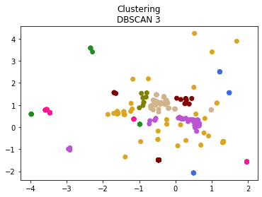

```python
# plot dbscan 3

colors = ['royalblue', 'maroon', 'forestgreen', 'mediumorchid', 'tan', 'deeppink', 'olive', 'goldenrod']
vectorizer = np.vectorize(lambda x: colors[x % len(colors)])

plt.scatter(X_norm[:,0], X_norm[:,1], c=vectorizer(labels_dbscan3))
plt.title('Clustering\nDBSCAN 3')
plt.show()
```

### Salvo il df con le labels del Dbscan3

```python
df_dbscan3 = df.copy()
df_dbscan3.insert(8, "Labels", labels_dbscan3, True)
#saving the dataframe
df_dbscan3.to_csv('../csv/df_dbscan3.csv')
```

## ODMatrix Dbscan3

```python
Labels = df_dbscan3['Labels']
Labels.value_counts()

# raggruppo il df in base agli utenti
Users = df_dbscan3.groupby(['Screen_name'])

# memorizzo i clusters in una lista
clusters = df_dbscan3['Labels'].unique().tolist()
clusters.sort()
clusters.insert(0, None)

odmatrix = ODMatrix(clusters, Users)

# creo la matrice
matrix_dbscan3 = odmatrix.create_matrix(clusters)

pairing_users = odmatrix.get_pairing_users(Users)

# ottengo la lista degli utenti che compiono spostamenti
moving_users = odmatrix.get_moving_users(pairing_users)
print("In questo dataframe ci sono ", len(moving_users), "utenti che compiono spostamenti.\n")

# aggiorno la matrice quando c'è uno spostamento
for user in moving_users:
    odmatrix.update_matrix(matrix_dbscan3, user)

print("Matrice finale:\n")
print(matrix_dbscan3)
```

```
In questo dataframe ci sono  25 utenti che compiono spostamenti.

Matrice finale:

[[nan -1.  0.  1.  2.  3.  4.  5.  6.  7.  8.  9. 10. 11. 12. 13. 14. 15.
  16. 17. 18. 19. 20. 21.]
 [-1.  0.  0.  0.  0.  0.  0.  0.  0.  0.  0.  0.  0.  0.  0.  0.  0.  0.
   0.  0.  0.  0.  0.  0.]
 [ 0.  0.  1.  1.  0.  0.  0.  0.  0.  0.  0.  0.  0.  0.  0.  0.  0.  0.
   0.  0.  0.  0.  0.  0.]
 [ 1.  0.  0.  4.  0.  3.  4.  0.  0.  2.  0.  1.  0.  0.  0.  0.  0.  0.
   0.  0.  0.  0.  0.  0.]
 [ 2.  0.  0.  0.  0.  0.  1.  0.  0.  0.  0.  0.  0.  0.  0.  0.  0.  0.
   0.  0.  0.  0.  0.  0.]
 [ 3.  2.  0.  2.  0.  8.  2.  0.  0.  2.  0.  0.  0.  1.  0.  0.  0.  0.
   0.  0.  0.  0.  0.  0.]
 [ 4.  1.  0.  0.  0.  3.  2.  0.  0.  0.  0.  0.  0.  0.  0.  0.  0.  0.
   0.  0.  0.  0.  0.  0.]
 [ 5.  0.  0.  0.  0.  0.  0.  0.  0.  0.  0.  0.  0.  0.  0.  0.  0.  0.
   0.  0.  0.  0.  0.  0.]
 [ 6.  0.  0.  0.  0.  0.  0.  0.  0.  0.  0.  0.  0.  0.  0.  0.  0.  0.
   0.  0.  0.  0.  0.  0.]
 [ 7.  0.  0.  2.  0.  0.  1.  0.  0.  1.  0.  0.  0.  0.  0.  0.  1.  0.
   0.  0.  0.  1.  0.  0.]
 [ 8.  0.  0.  0.  0.  0.  0.  0.  0.  0.  0.  0.  0.  0.  0.  0.  0.  0.
   0.  0.  0.  0.  0.  0.]
 [ 9.  1.  0.  0.  0.  0.  0.  0.  0.  0.  0.  0.  0.  0.  0.  0.  0.  0.
   0.  0.  0.  0.  0.  0.]
 [10.  0.  0.  0.  0.  0.  0.  1.  0.  0.  0.  0.  0.  0.  0.  0.  0.  0.
   0.  0.  0.  0.  0.  0.]
 [11.  0.  0.  0.  0.  0.  0.  1.  0.  0.  0.  0.  0.  0.  0.  0.  0.  0.
   0.  0.  0.  0.  0.  0.]
 [12.  0.  0.  0.  0.  0.  0.  0.  0.  0.  0.  0.  0.  0.  0.  0.  0.  0.
   0.  0.  0.  0.  0.  0.]
 [13.  0.  0.  0.  0.  0.  0.  0.  0.  0.  0.  0.  0.  0.  0.  0.  0.  0.
   0.  0.  0.  0.  0.  0.]
 [14.  1.  0.  0.  0.  0.  0.  0.  0.  0.  0.  0.  0.  0.  0.  0.  0.  0.
   0.  0.  0.  0.  0.  0.]
 [15.  0.  0.  0.  0.  0.  0.  0.  0.  0.  0.  0.  0.  0.  0.  0.  0.  0.
   0.  0.  0.  0.  0.  0.]
 [16.  0.  0.  1.  0.  0.  0.  0.  0.  0.  0.  0.  0.  0.  0.  0.  0.  0.
   1.  0.  0.  0.  0.  0.]
 [17.  0.  0.  0.  0.  0.  0.  0.  0.  0.  0.  0.  0.  0.  0.  0.  0.  0.
   0.  0.  0.  0.  0.  0.]
 [18.  0.  0.  0.  0.  0.  0.  0.  0.  0.  0.  0.  0.  0.  0.  0.  0.  0.
   0.  0.  0.  0.  0.  0.]
 [19.  0.  0.  0.  0.  0.  2.  0.  0.  0.  0.  0.  0.  0.  0.  0.  0.  0.
   0.  0.  0.  0.  0.  0.]
 [20.  0.  0.  0.  0.  0.  0.  0.  0.  0.  0.  0.  0.  0.  0.  0.  0.  0.
   0.  0.  0.  0.  0.  0.]
 [21.  0.  0.  0.  0.  0.  0.  0.  0.  0.  0.  0.  0.  0.  0.  0.  0.  0.
   0.  0.  0.  0.  0.  0.]]
```

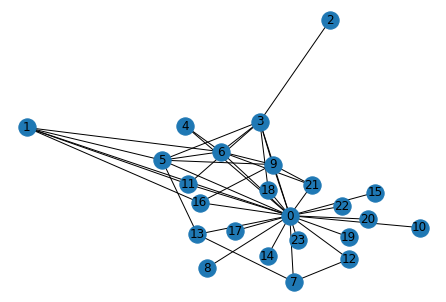

```python
G3 = nx.from_numpy_matrix(np.array(matrix_dbscan3))
nx.draw(G3, with_labels=True)
```

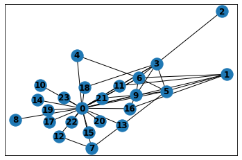

```python
nx.draw_networkx(G3, with_labels=True, font_weight='bold')
```

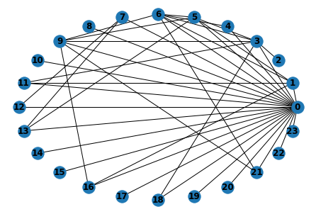

```python
nx.draw_circular(G3, with_labels=True, font_weight='bold')
```

## Applico Pattern Mining su df di DBSCAN

```python
ps = PSpan(df_dbscan3)
# converto Created_At in datetime
df_dbscan3['Created_At'] = pd.to_datetime(df_dbscan3['Created_At'])
# ordino i valori per data
df_dbscan3 = df_dbscan3.sort_values(by=['Created_At'])
dbscan_ps = ps.ps3(df_dbscan3)
dbscan_ps
```

```
[(20, [3, 3, 3]),
 (11, [3, 3, 3, 3]),
 (7, [1, 1, 1]),
 (6, [4, 4, 4]),
 (6, [3, 3, 3, 3, 3]),
 (5, [4, 4, 3]),
 (5, [4, 4, 1]),
 (4, [3, 3, 4]),
 (4, [3, 3, 3, 3, 3, 3]),
 (4, [1, 3, 3]),
 (4, [1, 1, 1, 1]),
 (3, [4, 4, 4, 3]),
 (3, [4, 4, 3, 1]),
 (3, [4, 3, 3]),
 (3, [4, 1, 4]),
 (3, [3, 3, 3, 4]),
 (3, [3, 3, 3, 3, 3, 3, 3, 3, 3]),
 (3, [3, 3, 1]),
 (3, [3, 1, 3])]
```

DBSCAN labels: it is possible to notice that the patterns with the highest frequency are also those that do not present real movements, but are those in which users have tweeted several times in the same place. Nevertheless, we can see the most crossed clusters are the 4th, 3rd and the 1st.

## Visualizzo i clusters e i patterns sulla mappa con folium

```python
X_dbscan3 = X.copy() # creo un nuovo dataframe per aggiungere le lables ottenute dal clustering con dbscan
X_dbscan3.insert(2, "Labels", labels_dbscan3, True)
```

```python
import folium
from folium import plugins

import matplotlib.pyplot as plt
import matplotlib.cm as cm
import matplotlib.colors as colors
```

```python
map_dbscan = folium.Map(location=loc, zoom_start=14.5)
c = len(np.unique(labels_dbscan3))

# set color scheme for the clusters
x = np.arange(c)
ys = [i + x + (i*x)**2 for i in range(c)]
colors_array = cm.rainbow(np.linspace(0, 1, len(ys)))
rainbow = [colors.rgb2hex(i) for i in colors_array]

# add markers to the map
markers_colors = []
for lat, lng, cluster in zip(X_dbscan3['Lat'], X_dbscan3['Lon'],
                                            X_dbscan3['Labels']):
    folium.vector_layers.CircleMarker(
        [lat, lng],
        radius=5,
        #popup=label,
        tooltip = 'Cluster ' + str(cluster),
        color=rainbow[cluster-1],
        fill=True,
        fill_color=rainbow[cluster-1],
        fill_opacity=0.9).add_to(map_dbscan)

#line going from dfw to lga
p1 = (43.71934, 10.4003)
p2 = (43.72263, 10.3948)

aline = folium.PolyLine(locations=[p1,p2], weight=2,color = 'red', tooltip='DBSCAN pattern 4-4-3')
arrow = folium.RegularPolygonMarker(location=p2, weight=2, color='red', fill_color='blue', number_of_sides=3, radius=4, rotation=0)
circle = folium.CircleMarker(location=p1, radius=2, color='red')

map_dbscan.add_child(aline)
map_dbscan.add_child(arrow)
map_dbscan.add_child(circle)

print('Mappa con clustering Dbscan 1 with noise')
map_dbscan
```

```
Mappa con clustering Dbscan 1 with noise
```

Make this Notebook Trusted to load map: File -> Trust Notebook

[interactive chart not shown]

# BISECTING-KMEANS

```python
X = df[['Lat', 'Lon']].copy()
X_geo = np.array(X.values.tolist())

max_distance_thr = 100 # meters
max_distance_thr = max_distance_thr / 1000 # kilometers

bkmeans = BisectingKMeans(min_cluster_size=1, max_distance_thr=max_distance_thr, metric='haversine', random_state=0)
bkmeans.fit(X_geo)
```

```python
values, counts = np.unique(bkmeans.labels_, return_counts=True)

print ('mean cluster dimension', statistics.mean(counts))
print ('median cluster dimension', statistics.median(counts))
print ('% outliers', 16*100/sum(counts))
print ('silhouette ', metrics.silhouette_score(X_geo, bkmeans.labels_, metric='euclidean'))
```

```
mean cluster dimension 12
median cluster dimension 4.0
% outliers 2.511773940345369
silhouette  0.8177508959704303
```

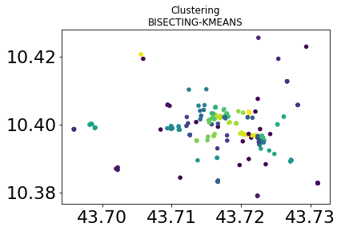

```python
%matplotlib inline
import matplotlib.pyplot as plt

plt.scatter(X_geo[:,0], X_geo[:,1], c=bkmeans.labels_, s=20)
plt.tick_params(axis='both', which='major', labelsize=22)
plt.title('Clustering\nBISECTING-KMEANS')
plt.show()
```

### Salvo il df con le labels del Bisecting-Kmeans

```python
df_bk = df.copy()
df_bk.insert(8, "Labels", bkmeans.labels_, True)
#saving the dataframe
df_bk.to_csv('../csv/df_bkmeans.csv')
```

## ODMatrix Bisecting-Kmeans

```python
# raggruppo il df in base agli utenti
Users = df_bk.groupby(['Screen_name'])

# memorizzo i clusters in una lista
clusters = df_bk['Labels'].unique().tolist()
clusters.sort()
clusters.insert(0, None)

odmatrix_bk = ODMatrix(clusters, Users)

# creo la matrice
matrix_bkmeans = odmatrix_bk.create_matrix(clusters)
matrix_bkmeans2 = odmatrix_bk.create_matrix(clusters)

# ottengo la lista degli utenti con clusters a coppie
pairing_users = odmatrix_bk.get_pairing_users(Users)

# ottendo la lista degli utenti che compiono spostamenti tra i clusters
moving_users = odmatrix_bk.get_moving_users(pairing_users)

print("In questo dataframe ci sono", len(pairing_users),
      "spostamenti anche nello stesso posto e", len(moving_users),
      "utenti che compiono spostamenti in luoghi diversi.\n")

# aggiorno la matrice anche per utenti che restano nello stesso posto
for user in pairing_users:
    odmatrix_bk.update_matrix(matrix_bkmeans, user)

# aggiorno la matrice solo quando c'è uno spostamento
for user in moving_users:
    odmatrix_bk.update_matrix2(matrix_bkmeans2, user)

print("Matrice con stesso luogo:\n")
print(matrix_bkmeans)
print()
print("Matrice con luoghi diversi:\n")
print(matrix_bkmeans2)
```

```
In questo dataframe ci sono 109 spostamenti anche nello stesso posto e 35 utenti che compiono spostamenti in luoghi diversi.

Matrice con stesso luogo:

[[nan -1.  0. ... 48. 49. 50.]
 [-1.  0.  0. ...  0.  0.  0.]
 [ 0.  0.  5. ...  0.  0.  0.]
 ...
 [48.  0.  0. ...  1.  0.  0.]
 [49.  0.  0. ...  0.  0.  0.]
 [50.  0.  0. ...  0.  0.  0.]]

Matrice con luoghi diversi:

[[nan -1.  0. ... 48. 49. 50.]
 [-1.  0.  0. ...  0.  0.  0.]
 [ 0.  0.  0. ...  0.  0.  0.]
 ...
 [48.  0.  0. ...  0.  0.  0.]
 [49.  0.  0. ...  0.  0.  0.]
 [50.  0.  0. ...  0.  0.  0.]]
```

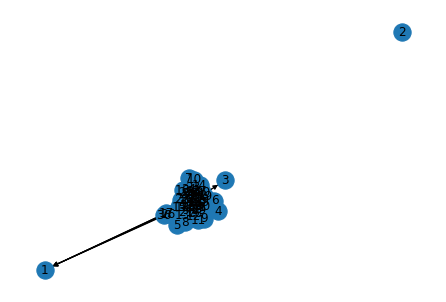

```python
Gbk = nx.from_numpy_matrix(np.array(matrix_bkmeans), create_using=nx.MultiDiGraph())
nx.draw(Gbk, with_labels=True)
```

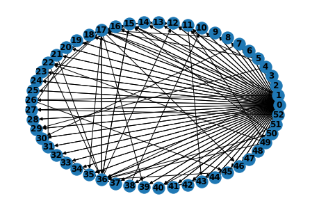

```python
nx.draw_circular(Gbk, with_labels=True, font_weight='bold', create_using=nx.MultiDiGraph())
```

```
Random Layout:
```

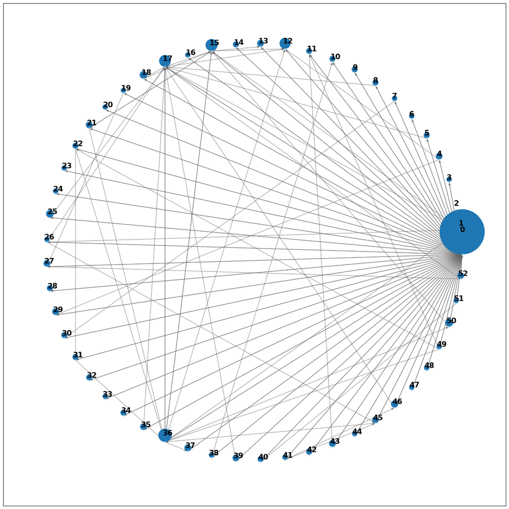

```python
import matplotlib.pyplot as plt

node_color = [Gbk.degree(v) for v in Gbk]
node_size = [0.0005 * Gbk.degree(v) for v in Gbk]

# Calculate centrality
centrality = nx.eigenvector_centrality_numpy(Gbk)

'''edge_width = [0.0015 * G[u][v]['weight'] for u, v in G.edges()]'''

plt.figure(figsize=(20,20))
ax = plt.gca()
ax.set_aspect('equal')

pos = nx.circular_layout(Gbk)
print("Random Layout:")

# demonstrating random layout
nx.draw_networkx(Gbk, pos, node_size = 10, font_weight='bold',
                 node_color = 'lightblue', alpha = 0.7,
                 with_labels = False,
                 edge_color ='.4', cmap = plt.cm.Blues)

for node, (x,y) in pos.items():
    rad = centrality[node]*0.16
    circle = plt.Circle((x,y+rad), radius=rad)
    plt.text(x-.012, y+rad, node, fontsize=16, weight="bold")
    ax.add_artist(circle)

plt.show()
```

## Applico Pattern Mining su df di BISECTING-KMEANS

```python
ps = PSpan(df_bk)
# converto Created_At in datetime
df_bk['Created_At'] = pd.to_datetime(df_bk['Created_At'])
# ordino i valori per data
df_bk = df_bk.sort_values(by=['Created_At'])
bkmeans_ps = ps.ps3(df_bk)
bkmeans_ps
```

```
[(7, [34, 34, 34]),
 (7, [15, 15, 15]),
 (5, [34, 34, 13]),
 (4, [34, 13, 13]),
 (4, [15, 15, 15, 15]),
 (4, [13, 13, 13]),
 (3, [47, 20, 34]),
 (3, [34, 34, 34, 34]),
 (3, [34, 34, 13, 13]),
 (3, [34, 13, 13, 13]),
 (3, [10, 10, 10])]
```

Bisecting-Kmeans labels: it is possible to notice that predictably the patterns with the highest frequency are also those that do not present real movements, but are those in which users have tweeted several times in the same place. Excluding those, we can see that many people frequently followed the path 34-34-13 or 34-13-13 or 47-20-34 (image).

## Visualizzo i clusters e i patterns sulla mappa con folium

```python
map_bk = folium.Map(location=[lat, lng], zoom_start=14.5)
c = len(np.unique(bkmeans.labels_))

# set color scheme for the clusters
x = np.arange(c)
ys = [i + x + (i*x)**2 for i in range(c)]
colors_array = cm.rainbow(np.linspace(0, 1, len(ys)))
rainbow = [colors.rgb2hex(i) for i in colors_array]

# add markers to the map
markers_colors1 = []
for lat, lng, cluster in zip(X_geo[:,0], X_geo[:,1],  bkmeans.labels_):
    #label = folium.Popup(str(city)+ ','+str(state) + '- Cluster ' + str(cluster), parse_html=True)
    folium.vector_layers.CircleMarker(
        [lat, lng],
        radius=5,
        #popup=label,
        tooltip = 'Cluster ' + str(cluster),
        color=rainbow[cluster-1],
        fill=True,
        fill_color=rainbow[cluster-1],
        fill_opacity=0.9).add_to(map_bk)

#line going from dfw to lga
p1 = (43.72040817, 10.39710583)
p2 = (43.7229514, 10.39497213)
p3 = (43.72305556, 10.39641667)

aline = folium.PolyLine(locations=[p1,p2,p3], weight=2,color = 'blue', tooltip='Bkmeans pattern 47-20-34')
arrow = folium.RegularPolygonMarker(location=p3, weight=2, color='blue', fill_color='blue', number_of_sides=3, radius=4, rotation=0)
circle = folium.CircleMarker(location=p1, radius=2, color='blue')

map_bk.add_child(aline)
map_bk.add_child(arrow)
map_bk.add_child(circle)

print('Mappa con clustering Bisecting Kmeans')
map_bk
```

```
Mappa con clustering Bisecting Kmeans
```

Make this Notebook Trusted to load map: File -> Trust Notebook

[interactive chart not shown]

# GEOHASH

```python
import pygeohash as pgh
import geohash as gh
import geopandas as gpd
from polygon_geohasher.polygon_geohasher import geohash_to_polygon
```

```python
X_geohash = X.copy()
X_geohash['geohash'] = X_geohash.apply(lambda x: gh.encode(x.Lat, x.Lon, precision=6), axis=1)
```

Conto i codici geohash per poi creare una mappa e creare la scala:

```python
count_geohash = []
codes_geohash = X_geohash['geohash'].tolist()
codes_geohash.sort()
```

```python
values = []

for code_geohash in codes_geohash:
    values.append(codes_geohash.count(code_geohash))

values_array = np.array(values)

values = set(values_array)
values
```

```
{1, 2, 4, 5, 6, 7, 12, 14, 27, 32, 53, 136, 318}
```

```python
norm = np.linalg.norm(values_array)
normal_array = values_array/norm
```

Creo un dataframe per poi costruire la griglia con i codici geohash sulla mappa folium:

```python
import json
# Create Geo Pandas DataFrame
df_geo = gpd.GeoDataFrame({'location':df_coords.tolist(), 'value': values_array})
df_geo['geohash'] = X_geohash['geohash']
df_geo['geometry'] = df_geo['geohash'].apply(geohash_to_polygon)
df_geo.crs = {'init': 'epsg:4326'}

display(json.loads(df_geo.to_json())['features'][0])
```

```
{'id': '0',
 'type': 'Feature',
 'properties': {'geohash': 'spz2ub',
  'location': '[43.72666207, 10.41268069]',
  'value': 4},
 'geometry': {'type': 'Polygon',
  'coordinates': [[[10.404052734375, 43.7255859375],
    [10.4150390625, 43.7255859375],
    [10.4150390625, 43.7310791015625],
    [10.404052734375, 43.7310791015625],
    [10.404052734375, 43.7255859375]]]}}
```

### Salvo il df con le labels del Geohashing

```python
df_geohash = df.copy()
df_geohash.insert(8, "geohash", X_geohash['geohash'] , True)
#saving the dataframe
df_geohash.to_csv('../csv/df_geohash.csv')
```

```python
# raggruppo il df in base ai codici geohash per cambiare nome in numeri e renderli più comprensibili
Geohash_codes = df_geohash.groupby(['geohash'])

lista = []
i = 0

for key, items in Geohash_codes:
    df_geohash['geohash'] = df_geohash['geohash'].replace(key, i)
    i = i+1
```

```python
#saving the dataframe
df_geohash.to_csv('../csv/df_geohash_to_numbers.csv')
```

```python
ps = PSpan(df_geohash)
# converto Created_At in datetime
df_geohash['Created_At'] = pd.to_datetime(df_geohash['Created_At'])
# ordino i valori per data
df_geohash = df_geohash.sort_values(by=['Created_At'])
geohash_ps = ps.ps3(df_geohash)
geohash_ps
```

```
[(21, [11, 11, 11]),
 (10, [11, 11, 11, 11]),
 (7, [5, 5, 5]),
 (6, [11, 11, 11, 11, 11]),
 (6, [10, 10, 11]),
 (6, [10, 10, 10]),
 (5, [11, 11, 10]),
 (5, [11, 11, 5]),
 (5, [10, 10, 5]),
 (5, [8, 8, 8]),
 (4, [11, 11, 11, 11, 11, 11]),
 (4, [11, 5, 11]),
 (4, [5, 11, 11]),
 (4, [5, 5, 5, 5]),
 (3, [11, 11, 11, 11, 11, 11, 11, 11, 11]),
 (3, [11, 11, 11, 10]),
 (3, [11, 11, 5, 10]),
 (3, [11, 10, 10, 10]),
 (3, [11, 10, 10, 5]),
 (3, [11, 5, 5]),
 (3, [10, 11, 11]),
 (3, [10, 10, 10, 11, 5]),
 (3, [10, 5, 10]),
 (3, [8, 8, 5]),
 (3, [5, 5, 8])]
```

Geohash labels: the patterns with the highest frequency are also those that do not present real movements, but are those in which users have tweeted several times in the same place (grid 11 and 5 mostly).

```python
map_geohash = folium.Map((lat, lng), zoom_start=13.2)
folium.Choropleth(geo_data=df_geo,
                  name='choropleth',
                  data=df_geo,
                  columns=['geohash', 'value'],
                  key_on='feature.properties.geohash',
                  fill_color='YlGn',
                  fill_opacity=0.7,
                  line_opacity=0.2,
                  legend_name='asdf').add_to(map_geohash)

#line going from dfw to lga
p1 = (43.71934, 10.4003)
p2 = (43.72263, 10.3948)

aline = folium.PolyLine(locations=[p1,p2], weight=2,color = 'green', tooltip='Geohash pattern 10-10-11')
arrow = folium.RegularPolygonMarker(location=p2, weight=2, color='green', fill_color='blue', number_of_sides=3, radius=4, rotation=0)
circle = folium.CircleMarker(location=p1, radius=2, color='green')

map_geohash.add_child(aline)
map_geohash.add_child(arrow)
map_geohash.add_child(circle)

map_geohash
```

Make this Notebook Trusted to load map: File -> Trust Notebook

[interactive chart not shown]